# RetinalDiseaseClassification

Alicia Sanguino y Sandra Pinel

## **PROCESAMIENTO DE IMAGEN IA - ALGORITMO DE CLASIFICACIÓN DE ENFERMEDADES DE LA RETINA**

La tarea consiste en crear un algoritmo que detecte a través de imágenes retinales si la persona padece o no de una enfermedad retinal. El modelo se creará a través del conjunto de datos proporcionados por la base de datos *'Retinal disease Classification'* de Kaggle: https://www.kaggle.com/datasets/andrewmvd/retinal-disease-classification

**IMPORTANCIÓN DE BIBLIOTECAS Y MÓDULOS NECESARIOS**

```python
#Conectamos el drive con el google Colab
from google.colab import drive
drive.mount('/content/drive')
```

```python
#Importanción de bibliotecas esenciales
import pandas as pd
import numpy as np
import matplotlib.pyplot as plt
import matplotlib.image as mpimg
import seaborn as sns
sns.set_style("whitegrid")

# Módulos para sistema de archivos
import os
import json

# Módulos para el entrenamiento y transfer learning
import tensorflow as tf
from tensorflow.keras.layers import Dense,Flatten
from tensorflow.keras.models import Sequential
from tensorflow.keras.optimizers import Adam
import tensorflow.keras.applications as cnns
from tensorflow.keras import Model

# Módulos para la evaluación del modelo
from sklearn.metrics import accuracy_score, classification_report, f1_score
from sklearn.metrics import roc_curve, precision_recall_curve

# Módulos para el ensamblaje
import collections

# Desactivación de logs de TensorFlow
import logging, os
logging.disable(logging.WARNING)
os.environ["TF_CPP_MIN_LOG_LEVEL"] = "3"

# Definición de constantes
TRAIN_CSV_DIR = "/content/drive/MyDrive/Trabajo_Retina/Training_Set/RFMiD_Training_Labels.csv"  #cambiar ruta a donde tengas tú la carpeta compartida con las imágenes
TEST_CSV_DIR = "/content/drive/MyDrive/Trabajo_Retina/Test_Set/RFMiD_Testing_Labels.csv"
```

En este primer código:

1. Se importan las bibliotecas esenciales como Pandas para manipulación de datos, NumPy para operaciones numéricas, Matplotlib y Seaborn para visualización. Y otras bibliotecas para el ensamblaje del modelo (`collections`).
1. Se importan módulos relacionados con el sistema de archivos para trabajar con directorios y archivos JSON; módulos de Tensor Flow y Keras para construir modelos de aprendizaje profundo; módulos de scikit-learn para evaluar el rendimiento del modelo, como la precisión y la puntuación F1.
2. Se desactivan los registros de Tensorflow para reducir la cantidad de información que se imprime en la consosola durante la ejecución del código, como mensajes de información o advertencia que no son esenciales para la compresión del código.
3. Se definen las constantes *TRAIN_CSV_DIR* y *TEST_CSV_DIR* que contienen las rutas a los archivos CSV con la información sobre las etiquetas de las imágenes que forman el conjunto de train y test.

**VERIFICACIÓN Y DETERMINACIÓN DEL ENTORNO DE EJECUCIÓN**

```python
# Lista de dispositivos físicos disponibles para Tensorflow
physical_devices = tf.config.list_physical_devices()
for device in physical_devices:
  print(device)
```

```
PhysicalDevice(name='/physical_device:CPU:0', device_type='CPU')
PhysicalDevice(name='/physical_device:GPU:0', device_type='GPU')
```

```python
# Verificar si hay al menos una GPU disponible
gpu_available = tf.test.is_gpu_available()

if gpu_available:
    print("Se está usando la GPU disponible en tu sistema.")
else:
    print("Se está usando la CPU disponible en tu sistema")
```

```
Se está usando la GPU disponible en tu sistema.
```

**VISUALIZACIÓN Y PROCESAMIENTO DE DATOS DEL CONJUNTO DE ENTRENAMIENTO Y TEST**

```python
#Leemos los datos de los archivos csv
train_data = pd.read_csv(TRAIN_CSV_DIR)
test_data = pd.read_csv(TEST_CSV_DIR)

#Vemos el tamaño del train-set y test-set
print("El conjunto de train tiene", len(train_data), "imágenes")
print("El conjunto de test tiene", len(test_data), "imágenes")
```

```
El conjunto de train tiene 1920 imágenes
El conjunto de test tiene 640 imágenes
```

```python
#Imprimimos las primeras filas del DataFrame de train_labels
train_data.head()
```

|  | ID | Disease_Risk | DR | ARMD | MH | DN | MYA | BRVO | TSLN | ERM | ... | CME | PTCR | CF | VH | MCA | VS | BRAO | PLQ | HPED | CL |
| --- | --- | --- | --- | --- | --- | --- | --- | --- | --- | --- | --- | --- | --- | --- | --- | --- | --- | --- | --- | --- | --- |
| 0 | 1 | 1 | 1 | 0 | 0 | 0 | 0 | 0 | 0 | 0 | ... | 0 | 0 | 0 | 0 | 0 | 0 | 0 | 0 | 0 | 0 |
| 1 | 2 | 1 | 1 | 0 | 0 | 0 | 0 | 0 | 0 | 0 | ... | 0 | 0 | 0 | 0 | 0 | 0 | 0 | 0 | 0 | 0 |
| 2 | 3 | 1 | 1 | 0 | 0 | 0 | 0 | 0 | 0 | 0 | ... | 0 | 0 | 0 | 0 | 0 | 0 | 0 | 0 | 0 | 0 |
| 3 | 4 | 1 | 0 | 0 | 1 | 0 | 0 | 0 | 0 | 0 | ... | 0 | 0 | 0 | 0 | 0 | 0 | 0 | 0 | 0 | 0 |
| 4 | 5 | 1 | 1 | 0 | 0 | 0 | 0 | 0 | 0 | 0 | ... | 0 | 0 | 0 | 0 | 0 | 0 | 0 | 0 | 0 | 0 |

5 rows × 47 columns

Creamos un diccionario llamado infected_retinas que contiene las dos patologías más frecuentes en las imágenes de retina. Esto se logra eliminando las columnas "ID" y "Disease_Risk" del DataFrame train_labels, sumando el número de ocurrencias de cada infección, ordenando los resultados en orden descendente y tomando las dos primeras entradas (que son las dos infecciones más frecuentes). Se prueba tanto para el conjunto de datos de train como el de test, para ver que que ambas obtienen el mismo resultado sobre las enfermedades más frecuentes:

```python
#Para el conjunto Train
sick_retinas = dict(train_data.drop(["ID", "Disease_Risk"], axis=1).sum().sort_values(ascending=False).head(2))
sick_retinas
```

```
{'DR': 376, 'MH': 317}
```

```python
#Para el conjunto Test
sick_retinas2 = dict(test_data.drop(["ID", "Disease_Risk"], axis=1).sum().sort_values(ascending=False).head(2))
sick_retinas2
```

```
{'DR': 124, 'MH': 104}
```

```python
#Creamos una lista con las claves ( 2 infecciones + frecuentes) del diccionario creado antes
list(sick_retinas.keys())
```

```
['DR', 'MH']
```

En ambas sale que las enfermedades más frecuentes son la 'Diabetic retinopathy' (DR) y 'Macular Hole' (MH). En español se conocen con el nombre de retinopatía diabética y agujero macular respectivamente.

```python
# Modificamos los Dataframes para incluir solo las columnas "ID" y las dos infecciones más frecuentes
train_data = train_data[["ID"]+list(sick_retinas.keys())]
test_data = test_data[["ID"]+list(sick_retinas.keys())]
```

Como nuestro objetivo es crear un modelo de clasificación binaria que nos diga si el paciente padece o no una patología retinal, hay que crear una nueva columna llamada "Etiquetas" que tiene el valor 1 si al menos uno de los valores en las columnas "Diabetic Retinopathy" o "Macular Hole" es 1, y 0 si ambos son 0. Después crearemos una nueva columna llamada 'Clase' que contendrá la palabra 'Enfermo' si el valor de la columna 'Enfermo' es 1, y 'No enfermo' si el valor es 0.

```python
# Crear la columna 'Etiquetas'
train_data['Etiquetas'] = train_data.apply(lambda row: 1 if row['DR'] == 1 or row['MH'] == 1 else 0, axis=1)
test_data['Etiquetas'] = test_data.apply(lambda row: 1 if row['DR'] == 1 or row['MH'] == 1 else 0, axis=1)

# Crear la columna 'Clase'
train_data['Clase'] = train_data['Etiquetas'].apply(lambda x: 'Enfermo' if x == 1 else 'No enfermo')
test_data['Clase'] = test_data['Etiquetas'].apply(lambda x: 'Enfermo' if x == 1 else 'No enfermo')
```

```python
train_data.head()
```

|  | ID | DR | MH | Etiquetas | Clase |
| --- | --- | --- | --- | --- | --- |
| 0 | 1 | 1 | 0 | 1 | Enfermo |
| 1 | 2 | 1 | 0 | 1 | Enfermo |
| 2 | 3 | 1 | 0 | 1 | Enfermo |
| 3 | 4 | 0 | 1 | 1 | Enfermo |
| 4 | 5 | 1 | 0 | 1 | Enfermo |

```python
test_data.head()
```

|  | ID | DR | MH | Etiquetas | Clase |
| --- | --- | --- | --- | --- | --- |
| 0 | 1 | 1 | 0 | 1 | Enfermo |
| 1 | 2 | 1 | 0 | 1 | Enfermo |
| 2 | 3 | 1 | 0 | 1 | Enfermo |
| 3 | 4 | 0 | 0 | 0 | No enfermo |
| 4 | 5 | 0 | 0 | 0 | No enfermo |

ESTO IR VIENDO COMO AJUSTAR: 1920 imágenes y 640 imágenes es una cantidad que sobrepasa nuestros límites y recursos. Para ellos seleccionaremos 200 imágenes para el entrenamiento y 60 imágenes para el testing. La selección de estas imágenes se hará de forma aleatoria y con un muestreo estratificado para evitar el desequilibrio de clases.

```python
from sklearn.model_selection import train_test_split

# Número total de imágenes que deseas seleccionar para entrenamiento y prueba
total_train_samples = 200
total_test_samples = 60

# Estratificación manual para garantizar la proporción de clases
train_stratified, _ = train_test_split(train_data, stratify=train_data["Etiquetas"], test_size=(len(train_data)-total_train_samples), random_state=42)
test_stratified, _ = train_test_split(test_data, stratify=test_data["Etiquetas"], test_size=(len(test_data)-total_test_samples), random_state=42)

# Muestreo aleatorio para seleccionar el número deseado de muestras
train_data = train_stratified.sample(n=total_train_samples, random_state=42)
test_data = test_stratified.sample(n=total_test_samples, random_state=42)
```

Observamos la forma de los Dataframes y calculamos la longitud de cada uno de los sets para comprobar que tengamos 200 y 60 respectivamente:

```python
train_data
print("El conjunto de train tiene", len(train_data), "imágenes")
```

```
El conjunto de train tiene 200 imágenes
```

```python
train_data
```

|  | ID | DR | MH | Etiquetas | Clase |
| --- | --- | --- | --- | --- | --- |
| 818 | 819 | 0 | 0 | 0 | No enfermo |
| 19 | 20 | 1 | 0 | 1 | Enfermo |
| 696 | 697 | 0 | 1 | 1 | Enfermo |
| 1819 | 1820 | 0 | 0 | 0 | No enfermo |
| 1568 | 1569 | 1 | 0 | 1 | Enfermo |
| ... | ... | ... | ... | ... | ... |
| 145 | 146 | 0 | 0 | 0 | No enfermo |
| 1714 | 1715 | 0 | 0 | 0 | No enfermo |
| 387 | 388 | 0 | 0 | 0 | No enfermo |
| 341 | 342 | 0 | 1 | 1 | Enfermo |
| 141 | 142 | 0 | 0 | 0 | No enfermo |

200 rows × 5 columns

```python
test_data
print("El conjunto de test tiene", len(test_data), "imágenes")
```

```
El conjunto de test tiene 60 imágenes
```

```python
test_data
```

|  | ID | DR | MH | Etiquetas | Clase |
| --- | --- | --- | --- | --- | --- |
| 2 | 3 | 1 | 0 | 1 | Enfermo |
| 103 | 104 | 0 | 1 | 1 | Enfermo |
| 38 | 39 | 0 | 0 | 0 | No enfermo |
| 475 | 476 | 0 | 0 | 0 | No enfermo |
| 561 | 562 | 0 | 0 | 0 | No enfermo |
| 424 | 425 | 0 | 0 | 0 | No enfermo |
| 266 | 267 | 0 | 0 | 0 | No enfermo |
| 146 | 147 | 1 | 0 | 1 | Enfermo |
| 531 | 532 | 0 | 0 | 0 | No enfermo |
| 515 | 516 | 0 | 0 | 0 | No enfermo |
| 116 | 117 | 0 | 0 | 0 | No enfermo |
| 139 | 140 | 1 | 0 | 1 | Enfermo |
| 158 | 159 | 0 | 1 | 1 | Enfermo |
| 14 | 15 | 0 | 0 | 0 | No enfermo |
| 619 | 620 | 0 | 0 | 0 | No enfermo |
| 477 | 478 | 1 | 0 | 1 | Enfermo |
| 172 | 173 | 0 | 0 | 0 | No enfermo |
| 75 | 76 | 0 | 1 | 1 | Enfermo |
| 629 | 630 | 0 | 0 | 0 | No enfermo |
| 582 | 583 | 0 | 0 | 0 | No enfermo |
| 442 | 443 | 0 | 0 | 0 | No enfermo |
| 135 | 136 | 0 | 0 | 0 | No enfermo |
| 324 | 325 | 0 | 0 | 0 | No enfermo |
| 610 | 611 | 0 | 1 | 1 | Enfermo |
| 264 | 265 | 1 | 0 | 1 | Enfermo |
| 179 | 180 | 1 | 0 | 1 | Enfermo |
| 47 | 48 | 0 | 0 | 0 | No enfermo |
| 638 | 639 | 0 | 0 | 0 | No enfermo |
| 186 | 187 | 0 | 1 | 1 | Enfermo |
| 613 | 614 | 0 | 0 | 0 | No enfermo |
| 63 | 64 | 0 | 0 | 0 | No enfermo |
| 91 | 92 | 0 | 0 | 0 | No enfermo |
| 380 | 381 | 0 | 0 | 0 | No enfermo |
| 64 | 65 | 0 | 0 | 0 | No enfermo |
| 368 | 369 | 0 | 0 | 0 | No enfermo |
| 634 | 635 | 0 | 0 | 0 | No enfermo |
| 260 | 261 | 0 | 1 | 1 | Enfermo |
| 560 | 561 | 0 | 0 | 0 | No enfermo |
| 387 | 388 | 0 | 0 | 0 | No enfermo |
| 166 | 167 | 1 | 0 | 1 | Enfermo |
| 85 | 86 | 1 | 0 | 1 | Enfermo |
| 499 | 500 | 0 | 0 | 0 | No enfermo |
| 241 | 242 | 0 | 1 | 1 | Enfermo |
| 490 | 491 | 0 | 0 | 0 | No enfermo |
| 216 | 217 | 0 | 1 | 1 | Enfermo |
| 528 | 529 | 0 | 0 | 0 | No enfermo |
| 624 | 625 | 0 | 0 | 0 | No enfermo |
| 129 | 130 | 0 | 1 | 1 | Enfermo |
| 102 | 103 | 0 | 0 | 0 | No enfermo |
| 131 | 132 | 0 | 0 | 0 | No enfermo |
| 162 | 163 | 0 | 0 | 0 | No enfermo |
| 616 | 617 | 0 | 0 | 0 | No enfermo |
| 632 | 633 | 0 | 1 | 1 | Enfermo |
| 101 | 102 | 0 | 0 | 0 | No enfermo |
| 208 | 209 | 1 | 0 | 1 | Enfermo |
| 95 | 96 | 0 | 0 | 0 | No enfermo |
| 41 | 42 | 0 | 0 | 0 | No enfermo |
| 510 | 511 | 0 | 1 | 1 | Enfermo |
| 348 | 349 | 1 | 0 | 1 | Enfermo |
| 93 | 94 | 0 | 0 | 0 | No enfermo |

Definimos una función para obtener la ruta de una imagen específica proporcionando el identificador y el directorio correspondiente:

```python
TRAIN_IMG_DIR="/content/drive/MyDrive/Trabajo_Retina/Training_Set/TRAIN"
TEST_IMG_DIR = "/content/drive/MyDrive/Trabajo_Retina/Test_Set/TEST"
def id_to_path(id : int, IMG_DIR : str):
    return os.path.join(IMG_DIR, str(id) + ".png")
```

Agregamos una nueva columna llamada "IMG_DIR" a los DataFrames train_labels y test_labels, y llenamos esta columna con las imágenes correspondientes utilizando la función id_to_path que definimos anteriormente. Así tenemos las imágenes asociadas a los datos de los Dataframes:

```python
train_data["IMG_DIR"] = TRAIN_IMG_DIR
train_data["IMG_DIR"] = train_data.apply(lambda x: id_to_path(x.ID, x.IMG_DIR),
                                             axis=1)
test_data["IMG_DIR"] = TEST_IMG_DIR
test_data["IMG_DIR"] = test_data.apply(lambda x: id_to_path(x.ID, x.IMG_DIR),
                                           axis=1)
```

```python
test_data.head()
```

|  | ID | DR | MH | Etiquetas | Clase | IMG_DIR |
| --- | --- | --- | --- | --- | --- | --- |
| 2 | 3 | 1 | 0 | 1 | Enfermo | /content/drive/MyDrive/Trabajo_Retina/Test_Set... |
| 103 | 104 | 0 | 1 | 1 | Enfermo | /content/drive/MyDrive/Trabajo_Retina/Test_Set... |
| 38 | 39 | 0 | 0 | 0 | No enfermo | /content/drive/MyDrive/Trabajo_Retina/Test_Set... |
| 475 | 476 | 0 | 0 | 0 | No enfermo | /content/drive/MyDrive/Trabajo_Retina/Test_Set... |
| 561 | 562 | 0 | 0 | 0 | No enfermo | /content/drive/MyDrive/Trabajo_Retina/Test_Set... |

```python
# Optativo: Descargar el archivo csv en formato xlsx para comprobar que cada imagen está bien asociada a su indentificador
train_data.to_excel('/content/modified_traindataframe.xlsx', index=False)
test_data.to_excel('/content/modified_testdataframe.xlsx', index=False)
```

A continuación vamos a ver la distribución de las clases en nuestro conjunto de datos de train y test para ver que no haya desembalance:

```python
# Contar el número de 0 y 1 en la columna 'Enfermo' del conjunto de train
enfermo_counts = train_data['Etiquetas'].value_counts()
# Mostrar el resultado
print("Número total de No Enfermos en train:", enfermo_counts[0])
print("Número total de Enfermos en train:", enfermo_counts[1])
```

```
Número total de No Enfermos en train: 130
Número total de Enfermos en train: 70
```

```python
enfermo_counts = test_data['Etiquetas'].value_counts()
print("Número total de No Enfermos en test:", enfermo_counts[0])
print("Número total de Enfermos en test:", enfermo_counts[1])
```

```
Número total de No Enfermos en test: 39
Número total de Enfermos en test: 21
```

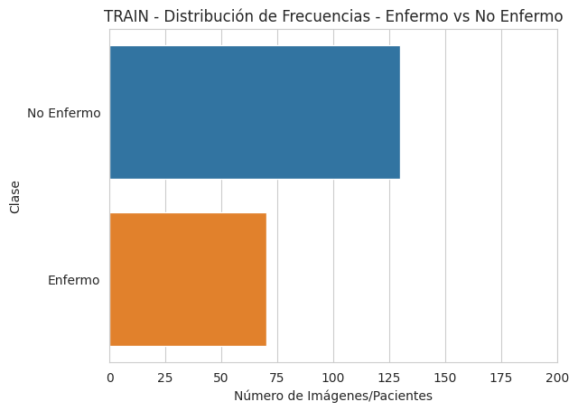

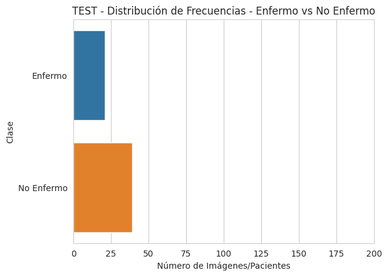

```python
import seaborn as sns
import matplotlib.pyplot as plt

def plot_distribution(labels, title):
    class_mapping = {0: 'No Enfermo', 1: 'Enfermo'}
    labels['Clase'] = labels['Etiquetas'].map(class_mapping)
    ax = sns.countplot(y='Clase', data=labels, orient='h')

    # Ajustar límites del eje x
    ax.set_xlim(0, 200)

    plt.title(f'{title} - Distribución de Frecuencias - Enfermo vs No Enfermo')
    plt.xlabel('Número de Imágenes/Pacientes')
    plt.ylabel('Clase')
    plt.show()

# Graficar la distribución de frecuencias para el conjunto de entrenamiento
plot_distribution(train_data, 'TRAIN')

# Graficar la distribución de frecuencias para el conjunto de prueba
plot_distribution(test_data, 'TEST')
```

**DEFINICIÓN DE CLASES PARA EL ENTRENAMIENTO Y EVALUACIÓN DEL MODELO**

```python
from keras.preprocessing.image import ImageDataGenerator
import pandas as pd
```

Este bloque de código define una clase ImagePreprocessor que se utiliza para preprocesar imágenes y crear generadores de datos antes de alimentarlas al modelo.

```python
class ImagePreprocessor:
    # Usar el método __init__ para definir los parámetros de inicialización
    def __init__(self, cnn_variant, input_size, labels):  #HEMOS QUITADO VAL
        self.cnn_variant = cnn_variant  #Almacena la variante de red neuronal convolucional que se usará para el preprocesamiento: MobileNetV2,Resnet50,etc...
        self.train_gen = None   #almacenar generadores de train y test (determinados por la función de abajo)
        self.test_gen = None
        self.input_size = input_size #tamaño de entrada deseado para las imágenes
        self.labels = labels #etiquetas que se utilizarán durante el entrenamiento

    # Método para crear generadores de imagen para el conjunto train y test
    def create_generators(self):
        self.train_gen = tf.keras.preprocessing.image.ImageDataGenerator(
            preprocessing_function=self.cnn_variant.preprocess_input            #se puede añadir rotaciones y otras cosas
        )

        self.test_gen = tf.keras.preprocessing.image.ImageDataGenerator(
            preprocessing_function=self.cnn_variant.preprocess_input
        )

    # Modifica el método preprocess en tu clase ImagePreprocessor
    def preprocess(self):
        train_images = self.train_gen.flow_from_dataframe(
        dataframe=train_data,
        x_col="IMG_DIR",
        y_col= "Clase",
        target_size=self.input_size,  # Este será el tamaño al que se redimensionarán las imágenes
        color_mode='rgb',
        batch_size=10,
        class_mode="binary",
        shuffle=True
    )

        test_images = self.test_gen.flow_from_dataframe(
        dataframe=test_data,
        x_col="IMG_DIR",
        y_col= "Clase",
        target_size=self.input_size,  # Este será el tamaño al que se redimensionarán las imágenes
        color_mode='rgb',
        batch_size=len(efficientnet_test),
        class_mode="binary",
        shuffle=False
    )

        return train_images, test_images
```

## COMO HEMOS QUITADO EL CONJUNTO DE VALIDACIÓN, VER SI ES NECESARIO CREAR UNO , VOY PONIENDO DE DONDE SE HA QUITADO

**1. Clase `ImagePreprocessor`**: Define una clase llamada ImagePreprocessor. Los parámetros de inicialización (**init**) incluyen la variante de CNN (cnn_variant), el tamaño de entrada de la imagen (input_size), y las etiquetas (labels) que se utilizarán para la clasificación.

**2. Método `create_generators`**: define un método llamado create_generators que va crear 2 generadores de datos (uno para train y otro para test) utilizando la variante de CNN especificada. Estos generadores aplican una función de preprocesamiento a las imágenes proporcionada por la variante de la red neuronal convolucional. Estas funciones suelen estar diseñadas para preparar las imágenes de acuerdo con los requisitos de entrada del modelo preentrenado. Por ejemplo, los modelos preentrenados en ImageNet a menudo requieren que las imágenes se normalicen de una manera específica

**3. Método `preprocess`**: este módulo se usa para vincular los DataFrames (train_data y test_data) a los generadores creados anteriormente. Utiliza flow_from_dataframe de Keras, especificando la columna que contiene las rutas de las imágenes (x_col), las etiquetas (y_col), el tamaño de destino de las imágenes (target_size), el modo de color (color_mode), el tamaño del lote (batch_size), el modo de clase (class_mode), y si se deben mezclar las muestras (shuffle). Finalmente, devuelve los generadores de imágenes preprocesadas para entrenamiento y prueba de nuestro caso.

La siguiente clase encapsula el proceso de transferencia de aprendizaje, marcando las capas no entrenables, agregando capas adicionales y compilando y entrenando el modelo.

```python
class TransferLearning:
    #Método de inicialización
    def __init__(self, train, model, classes : int) -> None:       #QUITADO VAL
        self.train = train #se refiere al conjunto de entrenamiento
        self.model = model
        self.history = None
        self.fine_tune_from = 100
        self.input_size = (200,200,3)  #esto depende del modelo que estés usando !!! --> EfficientNetB0
        self.classes = classes

    def mark_layers_non_trainable(self):
        for layer in self.model.layers:
            layer.trainable = False
    def add_final_layer(self):
        self.x = Flatten()(self.model.output)
        self.x = Dense(1000, activation='relu')(self.x)
        self.predictions = Dense(1, activation = 'sigmoid')(self.x)

    def compile_model(self):
        self.model = Model(inputs = self.model.input,
                           outputs = self.predictions)
        self.model.compile(optimizer='adam',
                           loss="binary_crossentropy",
                           metrics=['accuracy',
                                    tf.keras.metrics.AUC(name="auc",from_logits=True),
                                    tf.keras.metrics.FalseNegatives(name="false_negatives"),
                                    tf.keras.metrics.FalsePositives(name="false_positives"),
                                    tf.keras.metrics.Precision(name="precision"),
                                    tf.keras.metrics.Recall(name="recall")])
    def train_model(self):
        self.history = self.model.fit(self.train,
                                  batch_size=32,
                                  epochs=10,
                                  callbacks=[
                                    tf.keras.callbacks.EarlyStopping(
                                        monitor='loss',  # Cambiado a 'loss' para monitorizar la pérdida de entrenamiento por haber QUITADO CONJUNTO VAL
                                        patience=5,
                                        restore_best_weights=True
                                    )
                                 ])
```

**2) `mark_layers_non_trainable(self)`**: este método marca todas las capas del modelo preentrenado como no entrenables. Esto es común cuando estás realizando transferencia de aprendizaje y solo deseas entrenar las capas añadidas recientemente.

**3) `add_final_layer(self)`**: este método agrega capas adicionales al modelo después de las capas existentes. En este caso, se añade una capa de aplanamiento (Flatten()), seguida de una capa densa con activación ReLU y otra capa densa de salida con activación sigmoide ya que estamos realizando una clasificación binaria.

**4) `compile_model(self)`**: este método compila el modelo. Combina el modelo preentrenado con las nuevas capas añadidas y configura la función de pérdida, el optimizador y las métricas para el entrenamiento.

Se define una función llamada experiment_model que es la que va a realizar el entrenamiento del modelo utilizando transfer learning. Encapsula el proceso completo de preparación de datos, configuración del modelo, entrenamiento y devolución de resultados:

```python
def experiment_model(preprocessing_function, model, input_size : tuple, target_label : str):
    preprocessor = ImagePreprocessor(preprocessing_function,
                                     input_size,
                                     target_label)
    preprocessor.create_generators()
    train, test = preprocessor.preprocess()
    modelbuilder = TransferLearning(train, model, classes=2)      #hemos quitado de aqui el val

    modelbuilder.mark_layers_non_trainable()
    modelbuilder.add_final_layer()
    modelbuilder.compile_model()
    modelbuilder.train_model()
    return modelbuilder.model, modelbuilder.history, test  #La función devuelve el modelo entrenado, el historial del entrenamiento y el conjunto de prueba.
```

**BALANCEO DE CLASES**

El balanceo de clases es importante en algoritmos de clasificación cuando las clases en los datos de entrenamiento (train_data) no tienen una distribución uniforme. Es decir, unas clases van a estar sobrerrepresentadas en comparación con otras. De forma que el modelo se va a ver influenciado y sesgado hacia las clases mayoritarias. Esto nos afecta especialmente, porque lo que se pretende es clasificar lo mejor posible y que la red no posea un rendimiento deficiente en la clasificación de clases minoritarias.

```python
import torch
import torch.nn as nn
import torch.nn.functional as F

class FocalLoss(nn.Module):
    def __init__(self, gamma=0, alpha=None, size_average=True):
        super(FocalLoss, self).__init__()
        self.gamma = gamma
        self.alpha = alpha
        if isinstance(alpha, (float, int)):
            self.alpha = torch.Tensor([alpha, 1 - alpha])
        if isinstance(alpha, list):
            self.alpha = torch.Tensor(alpha)
        self.size_average = size_average

    def forward(self, input, target):
        if input.dim() > 2:
            input = input.view(input.size(0), input.size(1), -1)  # N,C,H,W => N,C,H*W
            input = input.transpose(1, 2)  # N,C,H*W => N,H*W,C
            input = input.contiguous().view(-1, input.size(2))  # N,H*W,C => N*H*W,C
        target = target.view(-1, 1)

        logpt = F.log_softmax(input, dim=1)
        logpt = logpt.gather(1, target)
        logpt = logpt.view(-1)
        pt = logpt.exp()

        if self.alpha is not None:
            if self.alpha.type() != input.data.type():
                self.alpha = self.alpha.type_as(input.data)
            at = self.alpha.gather(0, target.view(-1))
            logpt = logpt * at

        loss = -1 * (1 - pt) ** self.gamma * logpt
        if self.size_average:
            return loss.mean()
        else:
            return loss.sum()

# Usar Focal Loss con alpha=0.9
criterion = FocalLoss(gamma=0, alpha=0.9)
```

Los parámetros específicos de la Focal Loss que se pueden ajustar según nuestras necesidades son gamma y alpha.

```python
efficientnet, history, efficientnet_test = experiment_model(cnns.efficientnet,
                                                            cnns.EfficientNetB0(include_top=False,
                                                                                input_shape=(200,200,3)),
                                                            (200,200), "Clase")
```

```
Downloading data from https://storage.googleapis.com/keras-applications/efficientnetb0_notop.h5
Found 200 validated image filenames belonging to 2 classes.
```

[output not shown]

**EVALUACIÓN DE MODELO**

```python
from sklearn.metrics import confusion_matrix

model=efficientnet

# Obtener las predicciones del modelo en el conjunto de prueba
predictions = model.predict(efficientnet_test).flatten()

# Convertir las predicciones a etiquetas binarias (0 o 1) basadas en el umbral óptimo
threshold = 0.5  # Puedes ajustar este umbral según tus necesidades
binary_predictions = (predictions > threshold).astype(int)

# Obtener las etiquetas verdaderas del conjunto de prueba
true_labels = efficientnet_test.labels

# Calcular la matriz de confusión
conf_matrix = confusion_matrix(true_labels, binary_predictions)

# Imprimir la matriz de confusión
print("Matriz de Confusión:")
print(conf_matrix)
```

[output not shown]

La matriz de confusión tiene la siguiente estructura:**[[verdaderos negativos, falsos positivos] [falsos negativos, verdaderos positivos]]**

Descarga del notebook en html:

```python
import os

# Obtén el directorio de trabajo actual
current_directory = os.getcwd()

# Imprime el directorio actual
print("Directorio actual:", current_directory)

# Lista los archivos en el directorio actual
print("Contenido del directorio:", os.listdir())
```

```
Directorio actual: /content
Contenido del directorio: ['.config', '.ipynb_checkpoints', 'RetinalDiseaseClassification.ipynb', 'RetinalDiseaseClassification.html', 'sample_data']
```

```python
!jupyter nbconvert --to html RetinalDiseaseClassification.ipynb
```

```
[NbConvertApp] Converting notebook RetinalDiseaseClassification.ipynb to html
[NbConvertApp] Writing 799631 bytes to RetinalDiseaseClassification.html
```